# 特征构建：我能生成新特征吗

Guangyao Zhao

2022-06-10T21:09:12-05:00

需要注意的是，之前使用的特征都是定量的。我们现在就开始转而研究分类数据。我们的主要目的是，使用现有特征构建全新的特征，让模型从中学习。

## 检查数据集

```python
import pandas as pd

X = pd.DataFrame({
    'city': ['tokyo', None, 'london', 'seattle', 'san francisco', 'tokyo'],
    'boolean': ['yes', 'no', None, 'no', 'no', 'yes'],
    'ordinal_column': [
        'somewhat like', 'like', 'somewhat like', 'like', 'somewhat like',
        'dislike'
    ],
    'quantitative_column': [1, 11, -.5, 10, None, 20]
})

print(X)
```

```
##             city boolean ordinal_column  quantitative_column
## 0          tokyo     yes  somewhat like                  1.0
## 1           None      no           like                 11.0
## 2         london    None  somewhat like                 -0.5
## 3        seattle      no           like                 10.0
## 4  san francisco      no  somewhat like                  NaN
## 5          tokyo     yes        dislike                 20.0
```

观察每一列，并识别每列的类型和等级：

- `boolean`：定类等级
- `city`：定类等级
- `ordinal_column`：定序等级
- `quantitative_column`：定比等级

## 填充分类特征

查看是否含有缺失值，先用`isnull()`方法，然后使用`sum()`查看哪列含有缺失值。

```python
X.isnull().sum()
```

```
## city                   1
## boolean                1
## ordinal_column         0
## quantitative_column    1
## dtype: int64
```

从上面结果可以看出，数据集中是含有空值的。可采用以下策略填补空值： - 定性：众数 - 定量：平均值

先对`city`进行填充：

```python
X['city'].fillna(X['city'].value_counts().index[0])
```

```
## 0            tokyo
## 1            tokyo
## 2           london
## 3          seattle
## 4    san francisco
## 5            tokyo
## Name: city, dtype: object
```

`boolean`依然有缺失值，使用同样的方法，构建一个自定义填充器，用来处理分类数据。

机器学习流水线的中间步骤只能是转换，所以必须实现`fit`和`transform`方法，从而最终预测期还需要实现`fit`方法。

## 自定义分类填充器

首先使用`sklearn`的`TransformerMixin`基类创建我们的自定义分类填充器。

```python
from sklearn.base import TransformerMixin


class CustomCategoryImputer(TransformerMixin):
    def __init__(self, cols=None):
        self.cols = cols

    def transform(self, df):
        X = df.copy()
        for col in self.cols:
            X[col].fillna(X[col].value_counts().index[0], inplace=True)
        return X

    def fit(self, *_):
        return self


# 应用上面的类进行数据填充
cci = CustomCategoryImputer(cols=['city', 'boolean'])
cci.fit_transform(X)
```

```
##             city boolean ordinal_column  quantitative_column
## 0          tokyo     yes  somewhat like                  1.0
## 1          tokyo      no           like                 11.0
## 2         london      no  somewhat like                 -0.5
## 3        seattle      no           like                 10.0
## 4  san francisco      no  somewhat like                  NaN
## 5          tokyo     yes        dislike                 20.0
```

定性数据已经填充完毕，下面进行定量填充，同样地来重写一个类。

```python
from sklearn.impute import SimpleImputer


class CustomQuantitativeImputer(TransformerMixin):
    def __init__(self, cols=None, strategy='mean'):
        self.cols = cols
        self.strategy = strategy

    def transform(self, df):
        X = df.copy()
        impute = SimpleImputer(strategy=self.strategy)
        for col in self.cols:
            X[col] = impute.fit_transform(X[[col]])
        return X

    def fit(self, *_):
        return self


cqi = CustomQuantitativeImputer(cols=['quantitative_column'], strategy='mean')
cqi.fit_transform(X)
```

```
##             city boolean ordinal_column  quantitative_column
## 0          tokyo     yes  somewhat like                  1.0
## 1           None      no           like                 11.0
## 2         london    None  somewhat like                 -0.5
## 3        seattle      no           like                 10.0
## 4  san francisco      no  somewhat like                  8.3
## 5          tokyo     yes        dislike                 20.0
```

也可以不分别调用转换数据，可使用流水线一次解决：

```python
from sklearn.pipeline import Pipeline

imputer = Pipeline([('quant', cqi), ('category', cci)])
imputer.transform(X)
```

```
##             city boolean ordinal_column  quantitative_column
## 0          tokyo     yes  somewhat like                  1.0
## 1          tokyo      no           like                 11.0
## 2         london      no  somewhat like                 -0.5
## 3        seattle      no           like                 10.0
## 4  san francisco      no  somewhat like                  8.3
## 5          tokyo     yes        dislike                 20.0
```

至此，缺失值已处理完毕。

在算法中，输入的特征必须是数值形式。有几种可把非数值型特征转化为数值特征。

## 定类等级的编码

在 pandas 中有个很方便的`get_dummies`方法，可以找到所有的分类变量并转化为分类变量：

```python
pd.get_dummies(X, columns=['city', 'boolean'],
               prefix_sep='_')  # 要转化为 one hot 形式，所以指定分隔符为_
```

```
##   ordinal_column  quantitative_column  ...  boolean_no  boolean_yes
## 0  somewhat like                  1.0  ...           0            1
## 1           like                 11.0  ...           1            0
## 2  somewhat like                 -0.5  ...           0            0
## 3           like                 10.0  ...           1            0
## 4  somewhat like                  NaN  ...           1            0
## 5        dislike                 20.0  ...           0            1
##
## [6 rows x 8 columns]
```

也可以自定义填充器：

```python
class CustomDummifier(TransformerMixin):
    def __init__(self, cols=None):  #
        self.cols = cols

    def transform(self, X):
        return pd.get_dummies(X, columns=self.cols)

    def fit(self, *_):
        return self


cd = CustomDummifier(cols=['boolean', 'city'])
cd.fit_transform(X)
```

```
##   ordinal_column  quantitative_column  ...  city_seattle  city_tokyo
## 0  somewhat like                  1.0  ...             0           1
## 1           like                 11.0  ...             0           0
## 2  somewhat like                 -0.5  ...             0           0
## 3           like                 10.0  ...             1           0
## 4  somewhat like                  NaN  ...             0           0
## 5        dislike                 20.0  ...             0           1
##
## [6 rows x 8 columns]
```

## 定序等级的编码

定序等级的编码就要稍微复杂一些，因为要保证顺序。在此离子中，顺序(dislike, somewhat like, like)用$0$,$1$,$2$表示：

```python
ordering = ['dislike', 'somewhat like', 'like']
X['ordinal_column'].map(lambda x: ordering.index(x))
```

```
## 0    1
## 1    2
## 2    1
## 3    2
## 4    1
## 5    0
## Name: ordinal_column, dtype: int64
```

将其放入流水线中：

```python
class CustomEncoder(TransformerMixin):
    def __init__(self, cols, ordering=None):
        self.cols = cols
        self.ordering = ordering

    def transform(self, df):
        X = df.copy()
        for col in self.cols:
            X[col] = X[col].map(lambda x: ordering.index(x))

        return X

    def fit(self, *_):
        return self


ce = CustomEncoder(cols=['ordinal_column'], ordering=ordering)
ce.fit_transform(X)
```

```
##             city boolean  ordinal_column  quantitative_column
## 0          tokyo     yes               1                  1.0
## 1           None      no               2                 11.0
## 2         london    None               1                 -0.5
## 3        seattle      no               2                 10.0
## 4  san francisco      no               1                  NaN
## 5          tokyo     yes               0                 20.0
```

```python
print(X)
```

```
##             city boolean ordinal_column  quantitative_column
## 0          tokyo     yes  somewhat like                  1.0
## 1           None      no           like                 11.0
## 2         london    None  somewhat like                 -0.5
## 3        seattle      no           like                 10.0
## 4  san francisco      no  somewhat like                  NaN
## 5          tokyo     yes        dislike                 20.0
```

## 将连续特征分箱

有时候如果数值数据是连续的，那么将其转化为分类变量可能是有意义的，比如手上的数据是年龄，但是年龄段可能更有意义。 Pandas 有个函数叫`cut`，可以将数据分箱（也称之为分桶）。

```python
pd.cut(X['quantitative_column'], bins=3)
```

```
## 0     (-0.52, 6.333]
## 1    (6.333, 13.167]
## 2     (-0.52, 6.333]
## 3    (6.333, 13.167]
## 4                NaN
## 5     (13.167, 20.0]
## Name: quantitative_column, dtype: category
## Categories (3, interval[float64, right]): [(-0.52, 6.333] < (6.333, 13.167] < (13.167, 20.0]]
```

当然也可以定义自己的`CustomCutter`供流水线使用：

```python
class CustomCutter(TransformerMixin):
    def __init__(self, cols, bins, labels=False):
        self.cols = cols
        self.bins = bins
        self.labels = labels

    def transform(self, df):
        X = df.copy()
        for col in self.cols:
            X[col] = pd.cut(X[col], bins=self.bins)
        return X

    def fit(self, *_):
        return self


cc = CustomCutter(cols=['quantitative_column'], bins=3)
cc.fit_transform(X)
```

```
##             city boolean ordinal_column quantitative_column
## 0          tokyo     yes  somewhat like      (-0.52, 6.333]
## 1           None      no           like     (6.333, 13.167]
## 2         london    None  somewhat like      (-0.52, 6.333]
## 3        seattle      no           like     (6.333, 13.167]
## 4  san francisco      no  somewhat like                 NaN
## 5          tokyo     yes        dislike      (13.167, 20.0]
```

设置流水线：

1. 用`impute`填充缺失值
2. 虚拟变量填充分类列
3. 对`ordinal_column`进行编码
4. 将`quantitative_column`分箱

```python
pipe = Pipeline([('imputer', imputer), ('dummify', cd), ('encode', ce),
                 ('cut', cc)])
pipe.fit(X)
```

```
## Pipeline(steps=[('imputer',
##                  Pipeline(steps=[('quant',
##                                   <__main__.CustomQuantitativeImputer object at 0x7fbd4abd62b0>),
##                                  ('category',
##                                   <__main__.CustomCategoryImputer object at 0x7fbd4998c940>)])),
##                 ('dummify',
##                  <__main__.CustomDummifier object at 0x7fbd4abd67f0>),
##                 ('encode', <__main__.CustomEncoder object at 0x7fbd4ac0f760>),
##                 ('cut', <__main__.CustomCutter object at 0x7fbd4ac0f4f0>)])
```

创建流水线对象后，转化 DataFrame

```python
pipe.transform(X)
```

```
##    ordinal_column quantitative_column  ...  city_seattle  city_tokyo
## 0               1      (-0.52, 6.333]  ...             0           1
## 1               2     (6.333, 13.167]  ...             0           1
## 2               1      (-0.52, 6.333]  ...             0           0
## 3               2     (6.333, 13.167]  ...             1           0
## 4               1     (6.333, 13.167]  ...             0           0
## 5               0      (13.167, 20.0]  ...             0           1
##
## [6 rows x 8 columns]
```

## 扩展数值特征

### 根据胸部加速度计识别动作的数据集

数据包含以下内容：

- 序号
- $x$轴加速度
- $y$轴加速度
- $z$轴加速度
- 标签

其中标签对应于：

1. 电脑前工作
2. 站立、走路和上下楼
3. 站立
4. 走路
5. 上下楼梯
6. 与人边走边聊
7. 站立着讲话

```python
df = pd.read_csv('data/1.csv')
df.columns = ['index', 'x', 'y', 'z', 'activity']
df.head()
```

```
##    index     x     y     z  activity
## 0    1.0  1667  2072  2047         1
## 1    2.0  1611  1957  1906         1
## 2    3.0  1601  1939  1831         1
## 3    4.0  1643  1965  1879         1
## 4    5.0  1604  1959  1921         1
```

我们的目标是预测`activity`列。所以首先需要击败的是空准确率。调用`value_counts()`方法，将`normalize`选项设置为`True`，以百分比列出常见动作：

```python
df['activity'].value_counts(normalize=True)
```

```
## 7    0.515372
## 1    0.207237
## 4    0.165292
## 3    0.068794
## 5    0.019637
## 6    0.017951
## 2    0.005711
## 0    0.000006
## Name: activity, dtype: float64
```

空准确率为$51.54\%$，这就意味着我们的模型准确率必须超过它才算有效。

```python
from sklearn.neighbors import KNeighborsClassifier
from sklearn.model_selection import GridSearchCV

X = df[['x', 'y', 'z']]
y = df[['activity']]

knn_params = {'n_neighbors': [3, 4, 5, 6]}  # 参数列表

knn = KNeighborsClassifier()
grid = GridSearchCV(knn, knn_params)
grid.fit(X, y)
```

```
## GridSearchCV(estimator=KNeighborsClassifier(),
##              param_grid={'n_neighbors': [3, 4, 5, 6]})
##
```

```python
print(grid.best_score_, grid.best_params_)  #获取最佳参数
```

```
## 0.7368738461538461 {'n_neighbors': 5}
```

### 多项式特征

创建多个特征时，一个关键方法是使用 sklearn 的`PolynomialFeature`类。比如输入二维的`[a,b]`，那么二阶的多项式特征为`[1,a,b,a^2,ab,b^2]`。

在实例化多项式特征时，需要了解三个参数：

1. `degree`
2. `interaction_only`：为布尔值，如果为真，则表示只生成互相影响的特征
3. `include_bias`：如果为真，则生成一列阶数为$0$的偏列差，也就是说全是数字$1$

```python
from sklearn.preprocessing import PolynomialFeatures

poly = PolynomialFeatures(degree=2, include_bias=False, interaction_only=False)

X_poly = poly.fit_transform(X)
pd.DataFrame(X_poly, columns=poly.get_feature_names()).head()
```

```
##        x0      x1      x2  ...       x1^2      x1 x2       x2^2
## 0  1667.0  2072.0  2047.0  ...  4293184.0  4241384.0  4190209.0
## 1  1611.0  1957.0  1906.0  ...  3829849.0  3730042.0  3632836.0
## 2  1601.0  1939.0  1831.0  ...  3759721.0  3550309.0  3352561.0
## 3  1643.0  1965.0  1879.0  ...  3861225.0  3692235.0  3530641.0
## 4  1604.0  1959.0  1921.0  ...  3837681.0  3763239.0  3690241.0
##
## [5 rows x 9 columns]
##
```

现在可以进行一些数据分析了。因为多项式特征的目的就是为了更好理解原始数据的特征交互情况，最好的可视化方法是关联热图：

```python
import seaborn as sns

sns.heatmap(
    pd.DataFrame(X_poly, columns=poly.get_feature_names()).head().corr())

poly = PolynomialFeatures(degree=2, include_bias=False,
                          interaction_only=True)  # 将 interaction_only 改为 True

X_poly = poly.fit_transform(X)
pd.DataFrame(X_poly, columns=poly.get_feature_names()).head()
```

```
##        x0      x1      x2      x0 x1      x0 x2      x1 x2
## 0  1667.0  2072.0  2047.0  3454024.0  3412349.0  4241384.0
## 1  1611.0  1957.0  1906.0  3152727.0  3070566.0  3730042.0
## 2  1601.0  1939.0  1831.0  3104339.0  2931431.0  3550309.0
## 3  1643.0  1965.0  1879.0  3228495.0  3087197.0  3692235.0
## 4  1604.0  1959.0  1921.0  3142236.0  3081284.0  3763239.0
##
```

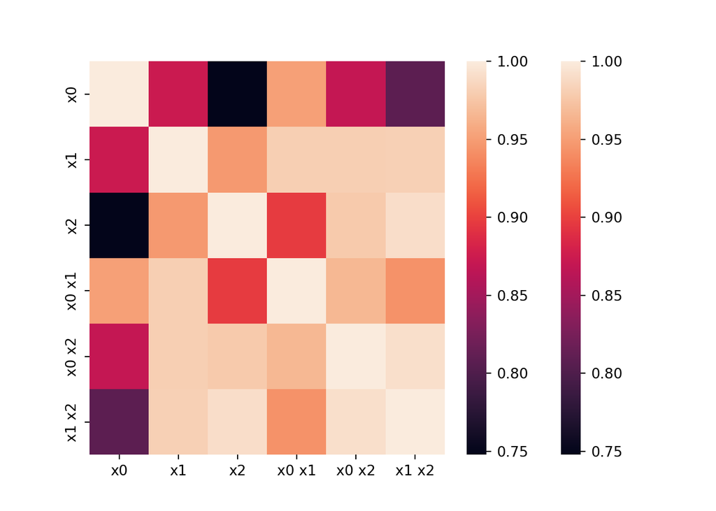

```python
sns.heatmap(
    pd.DataFrame(X_poly, columns=poly.get_feature_names()).head().corr())
```

还可以使用含有多项式特征对 KNN 进行网格搜索。

```python
pipe_params = {
    'poly_features__degree': [2],
    'poly_features__interaction_only': [True, False],
    'classify__n_neighbors': [3]
}  # 设置流水线参数，注意poly_features__interaction_only中是两个下划线

from sklearn.pipeline import Pipeline

pipe = Pipeline([('poly_features', poly), ('classify', knn)])

grid = GridSearchCV(pipe, pipe_params)
grid.fit(X, y)
```

```
## GridSearchCV(estimator=Pipeline(steps=[('poly_features',
##                                         PolynomialFeatures(include_bias=False,
##                                                            interaction_only=True)),
##                                        ('classify', KNeighborsClassifier())]),
##              param_grid={'classify__n_neighbors': [3],
##                          'poly_features__degree': [2],
##                          'poly_features__interaction_only': [True, False]})
##
```

```python
print(grid.best_score_, grid.best_params_)
```

```
## 0.7247938461538462 {'classify__n_neighbors': 3, 'poly_features__degree': 2, 'poly_features__interaction_only': True}
```